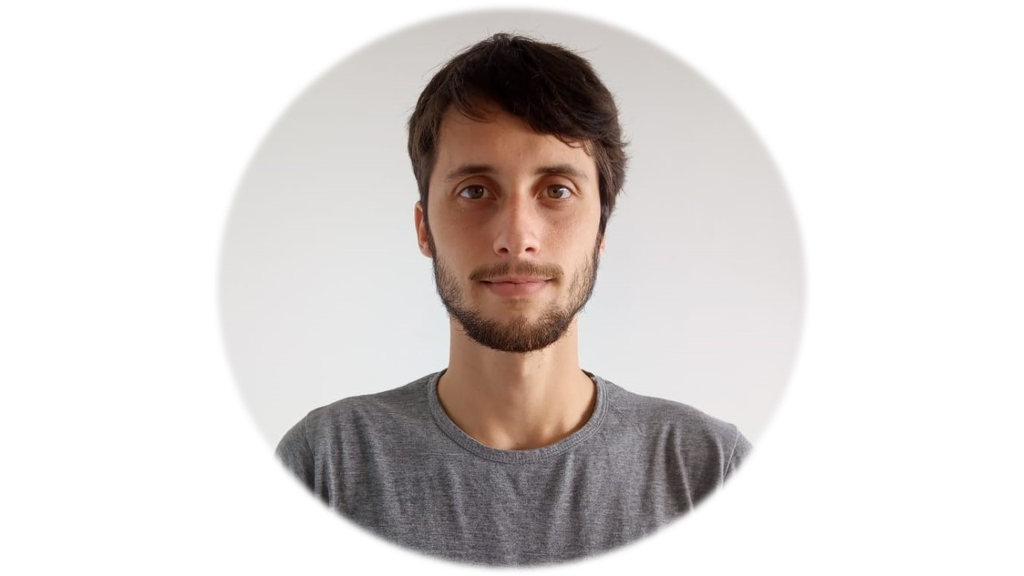

# David Gonilski-Pacin

## Bio

I am Molecular Biologist PhD Student at the [Buenos Aires University (UBA)](https://www.uba.ar/internacionales/index.php?lang=en), Argentina working in the [Biomedicine Institute of Buenos Aires](http://ibioba-mpsp-conicet.gov.ar/index.php/en/). I am highly interested in understanding the genetic regulatory networks and molecular signal pathways that drive kidney cancer.

## Research

The main aim of my study is to understand the mechanisms behind tumorigenesis and improve treatments in kidney cancer. I focus on the RSUME oncogene’s involvement in the development of Von Hippel Lindau tumors. I analyze genomic and transcriptomic datasets and perform wet lab experiments to support my findings.

## Education

| **University of Buenos Aires, Argentina** | 2019 - Present |
| --- | --- |
| Ph.D. in Kidney Cancer Biology |  |
| **Cold Spring Harbor Laboratory, New York** | July 2023 |
| Statistical Analysis of Genome Scale Data |  |
| **University of Buenos Aires, Argentina** | 2012 - 2019 |
| Licenciatura (seven-year degree equivalent to Bachelor and Master combined) in Biological Sciences |  |

## Technical Skills

| **Experimental** | **Bioinformatic** |
| --- | --- |
| Cell Culture | R and Bioconductor |
| Immunofluorescent Staining | Python |
| Angiogenesis and Tumorigenesis assays | FIJI |
| Confocal and Widefield Microscopy | Microarray analysis |
| RNA Isolation and cDNA Synthesis | RNA-seq analysis |
| PCR and Western blot |  |

## Teaching

| **University of Jose C. Paz, Argentina** | 2021-present |
| --- | --- |
| Teaching as chief of practical applications, University of Jose C. Paz. Courses taught: Biostatistics and Demography, Microbiology and Parasitology. |  |
| **University of Buenos Aires, Argentina** | 2019-2021 |
| Teaching assistant, University of Buenos Aires. Courses taught: Introduction to Molecular Bioinformatics, Biological Chemistry, Genetics I. |  |

## Published Works

**[Expression of RSUME is Associated With Poor Prognosis in Clear Cell Renal Carcinoma: Involvement of ROS Related Metabolism](https://www.sciencedirect.com/science/article/pii/S1558767323000678?casa_token=3_WXMMbAo9EAAAAA:CrOUVzqr_Flu8_l4UI54mkudacVHV5ObrPX6JgVrX8FsNmlmWYtXxiUrmKsxuKlQTo293Dnp-A)** | David Gonilski Pacin, Nicolás Ciancio del Giudice, Belén Elguero, Eduardo Arzt. Clinical Genitourinary Cancer (2023)

**[Impact of RSUME Actions on Biomolecular Modifications in Physio-Pathological Processes](https://www.frontiersin.org/articles/10.3389/fendo.2022.864780/full)** | Mariana Fuertes, Belén Elguero, David Gonilski-Pacin, …, Eduardo Arzt “Impact of RSUME Actions on Biomolecular Modifications in Physio-Pathological Processes”. Review article in Frontiers in Endocrinology (2022).

**[von Hippel-Lindau mutants in renal cell carcinoma are regulated by increased expression of RSUME](https://www.nature.com/articles/s41419-019-1507-3)** | Lucas Tedesco, Belen Elguero, David Gonilski Pacin, …, Eduardo Arzt. “von Hippel-Lindau mutants in renal cell carcinoma are regulated by increased expression of RSUME”. Cell Death & Disease (2019)

**[Mass Spectrometry-Based Metabolic Fingerprinting Contributes to Unveil the Role of RSUME in Renal Cell Carcinoma Cell Metabolism](https://pubs.acs.org/doi/full/10.1021/acs.jproteome.0c00655)** | Manuela Martinefski, Belen Elguero, María Knott, David Gonilski Pacin, …, Eduardo Arzt, María Eugenia Monge. Journal of Proteome Research (2021).

## Interests and Hobbies

You can usually find me rowing or playing soccer! I also love singing and playing the guitar.